# Sampling Distributions

STAT 240 - Fall 2025

Robert Sholl

# Motivation

You’re a head brewing chemist at a large scale brewery. You’ve been tasked to develop a new product that minimizes costs, maximizes quality, and appeals to a broad audience.

## Brewing

- Low cost, high quality, and unoffensive to the masses?
  - That’s a German beer
- Barley, hops, and water
- Barley and hop flavor notes are a lie, focus on yield
- Water is the only thing that matters for quality

## Cost Reduction

To develop this beer we have to run an experiment.

- Samples can get *very* expensive

In as few samples as possible we need to determine:

- The highest yield crop varieties
- The location with the highest quality water source

## In-class Activity

Take 5 minutes and pair up into groups.

- Think about what skills your group members will need
- Each group *at least* needs someone ready to speak up at the end

## Challenge 1

- You have $\$85000$ of company funds at your disposal
- Every sample has a cost to it:
  - $\$500$ per sample for Barley experiments
  - $\$800$ per sample for Hop experiments
  - $\$2000$ per sample for water testing
- The head brewer will only use the recipe you suggest if the data **AND** your explanation justify its use

## Challenge 1

- For each “correct” ingredient, you’ll see a $150\%$ return on investment
  - “Second best” ingredients see $80\%$ return
  - “Third best” see $20\%$
  - Anything else results in a $30\%$ loss
- You’ll have 2 minutes with each data source to make your decisions
- You’ll have 5 minutes to develop your “defense” of your recipe

## Barley

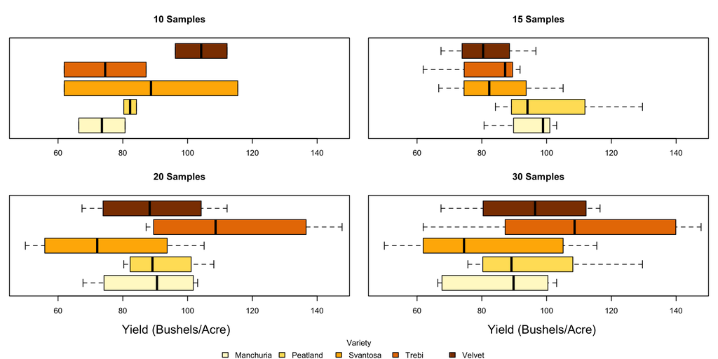

## Hops

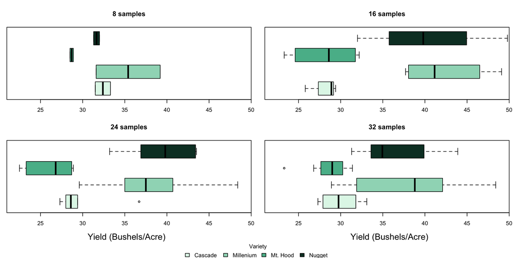

## Water

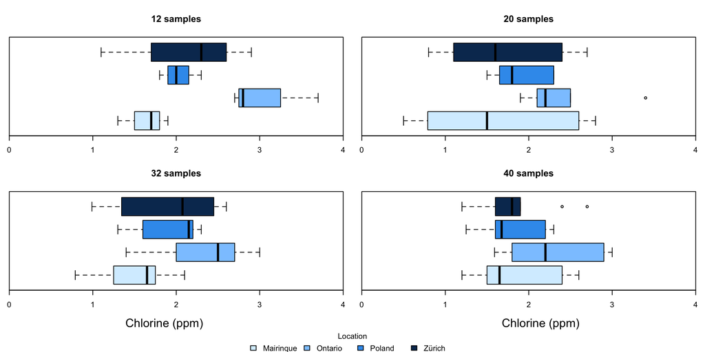

# Results

# Sampling Distributions

## Student’s $t$-distribution

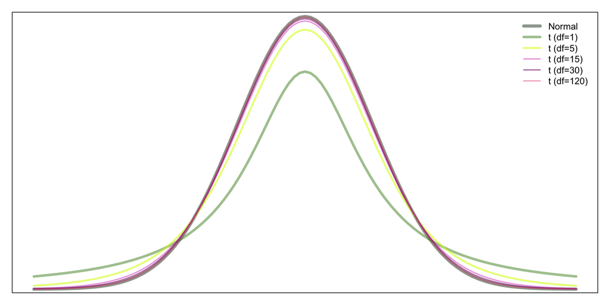

## Student’s $t$-distribution

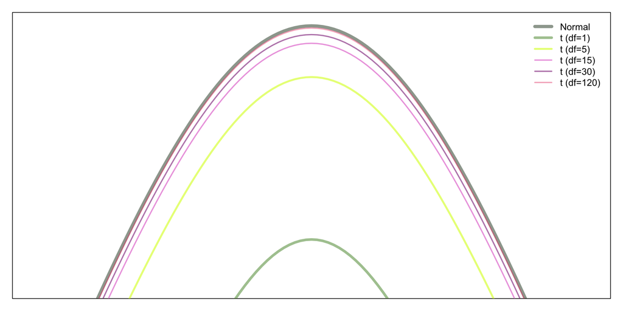

## Central Limit Theorem

- I’ll attempt this explanation
- I am not as good as [this guy](https://www.youtube.com/watch?v=zeJD6dqJ5lo)
  - I highly suggest you watch this, but it’s 31 minutes so that’s a *you* problem

## Central Limit Theorem

- Pull cards from a deck of 52 playing cards
  - Pull cards until you hit the queen of hearts
  - Record how many cards you pulled to get there, shuffle the deck, and repeat
- If you shuffle perfectly:
  - All possible positions are equally likely
  - Thus the chance of hitting a “center” queen is equally fair

## Central Limit Theorem

- The proper representation of reality would be:

> How often do people pull the queen in the center of the deck, on average?
- Zoom out and look at average results, i.e.
  - Each person pulls cards until the queen of hearts 20 times
  - That number is averaged and plotted out

## Central Limit Theorem

[figure not shown]

## Why does this matter?

Who actually won our little competition?

- The answer feels obvious, but it isn’t
- The CLT holds as $n \rightarrow \infty$
- At smaller samples we need the $t$-distribution
  - That’s not very convenient though

## Distribution of Statistics

In practice, the convergence can happen much quicker

- For any sample mean $\bar x$:

$$\text{When } n>30, \quad \bar x \sim N(\mu_{\bar x}, \sigma^2_{\bar x})$$

Where:

$$\mu_{\bar x} = \mu \quad \text{and} \quad \sigma^2_{\bar x} = \frac{\sigma^2}{n}$$

## Challenge 2

The “correct” ingredient can be described as the one that has the highest probability of the best outcome

- You’ll be given the mean and variance of each ingredient
- With the sample sizes you chose:
  - Find the probability that you achieve the “best” ingredients $\text{Q}_3$ (noted with *)
- The team with the highest probabilities for each wins

## Barley

$$\begin{array}{|c|}
\hline
\text{Ingredient} & \text{Mean} & \text{Variance} & \text{Q}_3\\
\hline
\text{Manchuria} & 103 & 674 & 115 \\
\hline
\text{Peatland} & 110 & 455 & 120 \\
\hline
\text{Svantosa} & 102 & 677 & 138 \\
\hline
\text{Trebi*} & 127 & 1345 & 138 \\
\hline
\text{Velvet} & 103 & 1066 & 123\\
\hline
\end{array}$$

## Hops

$$\begin{array}{|c|}
\hline
\text{Ingredient} & \text{Mean} & \text{Variance} & \text{Q}_3\\
\hline
\text{Cascade} & 31.7 & 42.7 & 33.0 \\
\hline
\text{Millennium} & 37.8 & 31.4 & 42.4 \\
\hline
\text{Mt. Hood} & 28.4 & 10.4 & 31.2 \\
\hline
\text{Nugget*} & 37.5 & 29.2 & 41.1 \\
\hline
\end{array}$$